# PEC 1

# *1. Seleccionar un dataset de metabolómica*

En mi caso, he seleccionado y descargado el dataset Cachexia procedente de https://github.com/nutrimetabolomics/metaboData/. Para trabajar con estos datos en R, cargamos el archivo “human_cachexia.csv” que tiene los datos con los que trabajaremos.

```r
# Indicar la ruta del archivo
ruta_archivo <- "D:/Máster bioinformática/Análisis de datos ómicos/PEC1/human_cachexia.csv"

# Cargar el archivo
cachexia <- read.csv(ruta_archivo)
```

# *2. Crear un contenedor del tipo SummarizedExperiment*

Para crear el contenedor, primero comprobaremos las columnas o variables de nuestro dataset, con el fin de identificar cuales corresponden a datos y cuales a metadatos, y así poder asignarlos adecuadamente.

```r
# Obtener el nombre de las columnas
colnames(cachexia)
```

```
##  [1] "Patient.ID"                  "Muscle.loss"
##  [3] "X1.6.Anhydro.beta.D.glucose" "X1.Methylnicotinamide"
##  [5] "X2.Aminobutyrate"            "X2.Hydroxyisobutyrate"
##  [7] "X2.Oxoglutarate"             "X3.Aminoisobutyrate"
##  [9] "X3.Hydroxybutyrate"          "X3.Hydroxyisovalerate"
## [11] "X3.Indoxylsulfate"           "X4.Hydroxyphenylacetate"
## [13] "Acetate"                     "Acetone"
## [15] "Adipate"                     "Alanine"
## [17] "Asparagine"                  "Betaine"
## [19] "Carnitine"                   "Citrate"
## [21] "Creatine"                    "Creatinine"
## [23] "Dimethylamine"               "Ethanolamine"
## [25] "Formate"                     "Fucose"
## [27] "Fumarate"                    "Glucose"
## [29] "Glutamine"                   "Glycine"
```

[output cut: 18 more lines]

Podemos observar que las dos primeras columnas corresponden a metadatos: Patient.ID (es el identificador de cada individuo) y Muscle.loss (indica a qué grupo pertenece cada individuo). El resto de columnas son variables que corresponden a metabolitos.

Teniendo esto en cuenta podremos crear nuestro contenedor SummarizedExperiment

```r
# Cargar la biblioteca SummarizedExperiment
library(SummarizedExperiment)
# Definir los metadatos ("Patient.ID" y "Muscle.loss") como las columnas
metadatos_cachexia <- cachexia[, 1:2]
colnames(metadatos_cachexia) <- c("Patient.ID", "Muscle.loss")

# Definir los datos de expresión (columnas correspondientes a los metabolitos)
datos_expresion <- as.matrix(cachexia[, 3:ncol(cachexia)])
datos_expresion <- t(datos_expresion)

# Crear un data frame para indicar en rowData que las variables corresponden a metabolitos
row_data <- data.frame(Metabolitos = rownames(datos_expresion))

# Crear el objeto SummarizedExperiment
contenedor_cachexia <- SummarizedExperiment(
  assays = list(counts = datos_expresion),
  colData = metadatos_cachexia,
  rowData = row_data
)

# Visualizar el objeto SummarizedExperiment que hemos creado
contenedor_cachexia
```

```
## class: SummarizedExperiment
## dim: 63 77
## metadata(0):
## assays(1): counts
## rownames(63): X1.6.Anhydro.beta.D.glucose X1.Methylnicotinamide ...
##   pi.Methylhistidine tau.Methylhistidine
## rowData names(1): Metabolitos
## colnames: NULL
## colData names(2): Patient.ID Muscle.loss
```

# *3. Exploración del dataset*

## *Análisis directo del dataset*

En primer lugar, podemos visualizar directamente el tamaño y estructura del dataset, así como obtener un resumen estadístico para cada variable.

```r
# Mostrar las dimensiones del dataset
dim(cachexia)
```

```
## [1] 77 65
```

```r
# Mostrar los nombres de las columnas
colnames(cachexia)
```

```
##  [1] "Patient.ID"                  "Muscle.loss"
##  [3] "X1.6.Anhydro.beta.D.glucose" "X1.Methylnicotinamide"
##  [5] "X2.Aminobutyrate"            "X2.Hydroxyisobutyrate"
##  [7] "X2.Oxoglutarate"             "X3.Aminoisobutyrate"
##  [9] "X3.Hydroxybutyrate"          "X3.Hydroxyisovalerate"
## [11] "X3.Indoxylsulfate"           "X4.Hydroxyphenylacetate"
## [13] "Acetate"                     "Acetone"
## [15] "Adipate"                     "Alanine"
## [17] "Asparagine"                  "Betaine"
## [19] "Carnitine"                   "Citrate"
## [21] "Creatine"                    "Creatinine"
## [23] "Dimethylamine"               "Ethanolamine"
## [25] "Formate"                     "Fucose"
## [27] "Fumarate"                    "Glucose"
## [29] "Glutamine"                   "Glycine"
```

[output cut: 18 more lines]

```r
# Mostrar los tipos de datos que tiene cada variable
str(cachexia)
```

```
## 'data.frame':    77 obs. of  65 variables:
##  $ Patient.ID                 : chr  "PIF_178" "PIF_087" "PIF_090" "NETL_005_V1" ...
##  $ Muscle.loss                : chr  "cachexic" "cachexic" "cachexic" "cachexic" ...
##  $ X1.6.Anhydro.beta.D.glucose: num  40.9 62.2 270.4 154.5 22.2 ...
##  $ X1.Methylnicotinamide      : num  65.4 340.4 64.7 53 73.7 ...
##  $ X2.Aminobutyrate           : num  18.7 24.3 12.2 172.4 15.6 ...
##  $ X2.Hydroxyisobutyrate      : num  26.1 41.7 65.4 74.4 83.9 ...
##  $ X2.Oxoglutarate            : num  71.5 67.4 23.8 1199.9 33.1 ...
##  $ X3.Aminoisobutyrate        : num  1480.3 116.8 14.3 555.6 29.7 ...
##  $ X3.Hydroxybutyrate         : num  56.83 43.82 5.64 175.91 76.71 ...
##  $ X3.Hydroxyisovalerate      : num  10.1 79.8 23.3 25 69.4 ...
##  $ X3.Indoxylsulfate          : num  567 369 665 412 166 ...
##  $ X4.Hydroxyphenylacetate    : num  120.3 432.7 292.9 214.9 97.5 ...
##  $ Acetate                    : num  126.5 212.7 314.2 37.3 407.5 ...
##  $ Acetone                    : num  9.49 11.82 4.44 206.44 44.26 ...
```

[output cut: 51 more lines]

Podemos observar que tenemos 77 muestras con 65 variables, siendo todas numéricas excepto Patient.ID y Muscle.loss, las cuales son de tipo character.

También podemos visualizar las primeras filas del dataset y obtener un resumen estadístico.

```r
# Mostrar las primeras filas
head(cachexia)
```

```
##    Patient.ID Muscle.loss X1.6.Anhydro.beta.D.glucose X1.Methylnicotinamide
## 1     PIF_178    cachexic                       40.85                 65.37
## 2     PIF_087    cachexic                       62.18                340.36
## 3     PIF_090    cachexic                      270.43                 64.72
## 4 NETL_005_V1    cachexic                      154.47                 52.98
## 5     PIF_115    cachexic                       22.20                 73.70
## 6     PIF_110    cachexic                      212.72                 31.82
##   X2.Aminobutyrate X2.Hydroxyisobutyrate X2.Oxoglutarate X3.Aminoisobutyrate
## 1            18.73                 26.05           71.52             1480.30
## 2            24.29                 41.68           67.36              116.75
## 3            12.18                 65.37           23.81               14.30
## 4           172.43                 74.44         1199.91              555.57
## 5            15.64                 83.93           33.12               29.67
## 6            18.36                 80.64           47.94               17.46
##   X3.Hydroxybutyrate X3.Hydroxyisovalerate X3.Indoxylsulfate
```

[output cut: 69 more lines]

```r
# Obtener un resumen estadístico de las columnas
summary(cachexia)
```

```
##   Patient.ID        Muscle.loss        X1.6.Anhydro.beta.D.glucose
##  Length:77          Length:77          Min.   :  4.71
##  Class :character   Class :character   1st Qu.: 28.79
##  Mode  :character   Mode  :character   Median : 45.60
##                                        Mean   :105.63
##                                        3rd Qu.:141.17
##                                        Max.   :685.40
##  X1.Methylnicotinamide X2.Aminobutyrate X2.Hydroxyisobutyrate X2.Oxoglutarate
##  Min.   :   6.42       Min.   :  1.28   Min.   : 4.85         Min.   :   5.53
##  1st Qu.:  15.80       1st Qu.:  5.26   1st Qu.:15.80         1st Qu.:  22.42
##  Median :  36.60       Median : 10.49   Median :32.46         Median :  55.15
##  Mean   :  71.57       Mean   : 18.16   Mean   :37.25         Mean   : 145.09
##  3rd Qu.:  73.70       3rd Qu.: 19.49   3rd Qu.:54.60         3rd Qu.:  92.76
##  Max.   :1032.77       Max.   :172.43   Max.   :93.69         Max.   :2465.13
##  X3.Aminoisobutyrate X3.Hydroxybutyrate X3.Hydroxyisovalerate X3.Indoxylsulfate
##  Min.   :   2.61     Min.   :  1.70     Min.   :  0.92        Min.   :  27.66
##  1st Qu.:  11.70     1st Qu.:  5.99     1st Qu.:  5.26        1st Qu.:  82.27
##  Median :  22.65     Median : 11.70     Median : 12.55        Median : 144.03
##  Mean   :  76.76     Mean   : 21.72     Mean   : 21.65        Mean   : 218.88
##  3rd Qu.:  56.26     3rd Qu.: 29.96     3rd Qu.: 30.27        3rd Qu.: 333.62
##  Max.   :1480.30     Max.   :175.91     Max.   :164.02        Max.   :1043.15
##  X4.Hydroxyphenylacetate    Acetate          Acetone          Adipate
##  Min.   : 15.49          Min.   :  3.49   Min.   :  2.29   Min.   :  1.55
##  1st Qu.: 41.68          1st Qu.: 16.28   1st Qu.:  4.95   1st Qu.:  6.11
##  Median : 70.11          Median : 39.65   Median :  7.10   Median : 10.18
##  Mean   :112.02          Mean   : 66.14   Mean   : 11.43   Mean   : 24.76
##  3rd Qu.:145.47          3rd Qu.: 86.49   3rd Qu.: 10.49   3rd Qu.: 19.11
##  Max.   :796.32          Max.   :411.58   Max.   :206.44   Max.   :327.01
##     Alanine          Asparagine        Betaine         Carnitine
##  Min.   :  16.78   Min.   :  6.69   Min.   :  2.29   Min.   :  2.18
##  1st Qu.:  78.26   1st Qu.: 20.49   1st Qu.: 28.79   1st Qu.: 14.44
##  Median : 194.42   Median : 42.10   Median : 64.72   Median : 23.81
##  Mean   : 273.56   Mean   : 62.28   Mean   : 90.32   Mean   : 52.09
##  3rd Qu.: 399.41   3rd Qu.: 89.12   3rd Qu.:127.74   3rd Qu.: 60.95
##  Max.   :1312.91   Max.   :273.14   Max.   :391.51   Max.   :487.85
##     Citrate            Creatine         Creatinine    Dimethylamine
##  Min.   :   59.74   Min.   :   2.75   Min.   : 1002   Min.   :  41.26
##  1st Qu.:  788.40   1st Qu.:  17.64   1st Qu.: 3498   1st Qu.: 142.59
##  Median : 1790.05   Median :  44.26   Median : 7631   Median : 304.90
##  Mean   : 2235.35   Mean   : 126.83   Mean   : 8734   Mean   : 358.17
```

[output cut: 64 more lines]

```
##  Max.   :259.82   Max.   :539.15   Max.   :179.47   Max.   :160.77
##      Xylose        cis.Aconitate      myo.Inositol    trans.Aconitate
##  Min.   :  10.07   Min.   :  12.94   Min.   : 11.59   Min.   :  4.90
##  1st Qu.:  29.96   1st Qu.:  36.23   1st Qu.: 30.27   1st Qu.: 12.43
##  Median :  50.40   Median : 129.02   Median : 78.26   Median : 26.84
##  Mean   : 100.93   Mean   : 204.22   Mean   :135.40   Mean   : 40.63
##  3rd Qu.:  89.12   3rd Qu.: 254.68   3rd Qu.:167.34   3rd Qu.: 57.40
##  Max.   :2164.62   Max.   :1863.11   Max.   :854.06   Max.   :217.02
##  pi.Methylhistidine tau.Methylhistidine
##  Min.   :  11.36    Min.   :  8.00
##  1st Qu.:  67.36    1st Qu.: 27.39
##  Median : 162.39    Median : 68.72
##  Mean   : 370.29    Mean   : 89.69
##  3rd Qu.: 387.61    3rd Qu.:130.32
##  Max.   :2697.28    Max.   :317.35
```

Comprobaremos si hay algún valor faltante.

```r
# Verificar si hay filas o columnas con NA
anyNA(cachexia)
```

```
## [1] FALSE
```

Observamos que en nuestro caso no hay ninguno.

## *Análisis utilizando el objeto SummarizedExperiment*

La información básica que ya hemos comprobado como las dimensiones o estructura del dataset también puede comprobarse a través del contenedor SummarizedExperiment que hemos creado.

```r
# Mostrar la estructura del contenedor
contenedor_cachexia
```

```
## class: SummarizedExperiment
## dim: 63 77
## metadata(0):
## assays(1): counts
## rownames(63): X1.6.Anhydro.beta.D.glucose X1.Methylnicotinamide ...
##   pi.Methylhistidine tau.Methylhistidine
## rowData names(1): Metabolitos
## colnames: NULL
## colData names(2): Patient.ID Muscle.loss
```

```r
# Visualizar los nombres de los metabolitos
rowData(contenedor_cachexia)
```

```
## DataFrame with 63 rows and 1 column
##                                        Metabolitos
##                                        <character>
## X1.6.Anhydro.beta.D.glucose X1.6.Anhydro.beta.D...
## X1.Methylnicotinamide        X1.Methylnicotinamide
## X2.Aminobutyrate                  X2.Aminobutyrate
## X2.Hydroxyisobutyrate        X2.Hydroxyisobutyrate
## X2.Oxoglutarate                    X2.Oxoglutarate
## ...                                            ...
## cis.Aconitate                        cis.Aconitate
## myo.Inositol                          myo.Inositol
## trans.Aconitate                    trans.Aconitate
## pi.Methylhistidine              pi.Methylhistidine
## tau.Methylhistidine            tau.Methylhistidine
```

```r
# Verificar si existen valores faltantes en el objeto `contenedor_cachexia`
anyNA(contenedor_cachexia)
```

```
## [1] FALSE
```

```r
# Visualizar los primeros datos de expresión
assay(contenedor_cachexia)[1:10, 1:10]
```

```
##                                [,1]   [,2]   [,3]    [,4]   [,5]   [,6]   [,7]
## X1.6.Anhydro.beta.D.glucose   40.85  62.18 270.43  154.47  22.20 212.72 151.41
## X1.Methylnicotinamide         65.37 340.36  64.72   52.98  73.70  31.82  36.60
## X2.Aminobutyrate              18.73  24.29  12.18  172.43  15.64  18.36   8.67
## X2.Hydroxyisobutyrate         26.05  41.68  65.37   74.44  83.93  80.64  42.52
## X2.Oxoglutarate               71.52  67.36  23.81 1199.91  33.12  47.94 223.63
## X3.Aminoisobutyrate         1480.30 116.75  14.30  555.57  29.67  17.46  56.26
## X3.Hydroxybutyrate            56.83  43.82   5.64  175.91  76.71  31.82  11.59
## X3.Hydroxyisovalerate         10.07  79.84  23.34   25.03  69.41  35.16  25.79
## X3.Indoxylsulfate            566.80 368.71 665.14  411.58 165.67 183.09 223.63
## X4.Hydroxyphenylacetate      120.30 432.68 292.95  214.86  97.51 132.95  59.15
##                               [,8]   [,9]  [,10]
## X1.6.Anhydro.beta.D.glucose  31.50  51.42 117.92
## X1.Methylnicotinamide         6.82  30.27  52.46
## X2.Aminobutyrate              4.18   7.54  19.49
## X2.Hydroxyisobutyrate        12.94  34.81  72.24
## X2.Oxoglutarate              25.03  80.64  73.70
## X3.Aminoisobutyrate           8.67  17.99  57.97
## X3.Hydroxybutyrate            1.73   9.03  26.84
## X3.Hydroxyisovalerate         8.76   3.25  28.50
## X3.Indoxylsulfate           111.05 391.51 116.75
## X4.Hydroxyphenylacetate      33.78 145.47  50.40
```

```r
# Mostrar los metadatos
colData(contenedor_cachexia)
```

```
## DataFrame with 77 rows and 2 columns
##       Patient.ID Muscle.loss
##      <character> <character>
## 1        PIF_178    cachexic
## 2        PIF_087    cachexic
## 3        PIF_090    cachexic
## 4    NETL_005_V1    cachexic
## 5        PIF_115    cachexic
## ...          ...         ...
## 73  NETCR_019_V2     control
## 74   NETL_012_V1     control
## 75   NETL_012_V2     control
## 76   NETL_003_V1     control
## 77   NETL_003_V2     control
```

```r
# Obtener el resumen estadístico de los datos de expresión
summary(datos_expresion)
```

```
##        V1                 V2                 V3                 V4
##  Min.   :    5.58   Min.   :    7.69   Min.   :    4.44   Min.   :   25.03
##  1st Qu.:   52.72   1st Qu.:   78.66   1st Qu.:   31.50   1st Qu.:  102.51
##  Median :  154.47   Median :  208.51   Median :  141.17   Median :  247.15
##  Mean   :  699.86   Mean   :  708.30   Mean   :  771.79   Mean   : 1021.28
##  3rd Qu.:  416.24   3rd Qu.:  412.10   3rd Qu.:  308.03   3rd Qu.:  673.71
##  Max.   :16481.60   Max.   :15835.35   Max.   :24587.66   Max.   :20952.22
##        V5                V6                 V7                V8
##  Min.   :   4.53   Min.   :    5.05   Min.   :   2.10   Min.   :   1.73
##  1st Qu.:  44.26   1st Qu.:   35.34   1st Qu.:  26.73   1st Qu.:   7.14
##  Median :  84.77   Median :  113.30   Median :  91.84   Median :  18.17
##  Mean   : 441.22   Mean   :  537.48   Mean   : 400.85   Mean   :  82.77
##  3rd Qu.: 196.62   3rd Qu.:  325.58   3rd Qu.: 223.63   3rd Qu.:  52.52
##  Max.   :6836.29   Max.   :15677.78   Max.   :8022.46   Max.   :2208.35
##        V9               V10               V11               V12
##  Min.   :   2.41   Min.   :   9.12   Min.   :   4.26   Min.   :    7.17
##  1st Qu.:  14.63   1st Qu.:  43.82   1st Qu.:  31.98   1st Qu.:   38.77
##  Median :  39.65   Median : 117.92   Median :  83.93   Median :  127.74
##  Mean   : 207.80   Mean   : 478.07   Mean   : 367.52   Mean   :  650.75
##  3rd Qu.: 102.00   3rd Qu.: 405.50   3rd Qu.: 182.20   3rd Qu.:  283.05
##  Max.   :6634.24   Max.   :8690.62   Max.   :8433.78   Max.   :19341.34
##       V13                V14                V15               V16
##  Min.   :    6.05   Min.   :    3.49   Min.   :   1.48   Min.   :   2.230
##  1st Qu.:   36.30   1st Qu.:   28.09   1st Qu.:   5.17   1st Qu.:   5.965
##  Median :   83.93   Median :   71.52   Median :  17.46   Median :  18.360
##  Mean   :  484.70   Mean   :  355.17   Mean   :  53.48   Mean   :  56.669
##  3rd Qu.:  218.11   3rd Qu.:  152.94   3rd Qu.:  40.65   3rd Qu.:  37.155
##  Max.   :15677.78   Max.   :12209.87   Max.   :1480.30   Max.   :1635.980
##       V17               V18                V19               V20
##  Min.   :   3.29   Min.   :    3.39   Min.   :   2.92   Min.   :    3.10
##  1st Qu.:  17.91   1st Qu.:   26.06   1st Qu.:  18.82   1st Qu.:   39.26
##  Median :  64.07   Median :   78.26   Median :  74.44   Median :   82.27
##  Mean   : 318.71   Mean   :  424.13   Mean   : 356.55   Mean   :  461.16
##  3rd Qu.: 164.90   3rd Qu.:  193.47   3rd Qu.: 176.13   3rd Qu.:  296.43
##  Max.   :9701.15   Max.   :10198.54   Max.   :6974.39   Max.   :11158.98
##       V21               V22                V23                V24
##  Min.   :   4.85   Min.   :    5.26   Min.   :    4.35   Min.   :   1.55
##  1st Qu.:  28.80   1st Qu.:   44.97   1st Qu.:   39.41   1st Qu.:   8.85
##  Median :  64.72   Median :   98.49   Median :   75.94   Median :  17.81
##  Mean   : 460.75   Mean   :  645.12   Mean   :  546.23   Mean   : 153.92
```

[output cut: 85 more lines]

```
##  Max.   :13493.99   Max.   :2298.470   Max.   :3165.29   Max.   :1002.250
##       V73                V74               V75               V76
##  Min.   :    3.67   Min.   :   1.84   Min.   :   2.69   Min.   :   2.51
##  1st Qu.:   22.12   1st Qu.:  10.70   1st Qu.:   9.30   1st Qu.:  14.88
##  Median :   58.56   Median :  21.33   Median :  24.05   Median :  34.12
##  Mean   :  342.26   Mean   : 142.84   Mean   : 147.55   Mean   : 159.46
##  3rd Qu.:  180.37   3rd Qu.:  63.44   3rd Qu.:  59.20   3rd Qu.:  90.47
##  Max.   :10097.06   Max.   :3789.54   Max.   :3498.19   Max.   :3498.19
##       V77
##  Min.   :   1.62
##  1st Qu.:  12.55
##  Median :  24.29
##  Mean   : 121.70
##  3rd Qu.:  80.70
##  Max.   :2864.07
```

## *Análisis en mayor profundidad*

*Normalizar los datos* Podemos utilizar el paquete POMA para imputar, normalizar y analizar nuestro objeto SummarizedExperiment.

```r
# Instalar y cargar el paquete POMA a través de BiocManager
if (!require("BiocManager", quietly = TRUE))
    install.packages("BiocManager")
BiocManager::install("POMA")
library(POMA)
```

Como ya hemos comprobado que en nuestro conjunto de datos no hay ningún valor faltante no sería necesario imputar y podemos pasar directamente a la normalización.

```r
# Normalizar los datos
contenedor_cachexia_normalizado <- contenedor_cachexia %>%
  PomaNorm(method = "log_pareto")

contenedor_cachexia_normalizado
```

```
## class: SummarizedExperiment
## dim: 63 77
## metadata(0):
## assays(1): ''
## rownames(63): X1.6.Anhydro.beta.D.glucose X1.Methylnicotinamide ...
##   pi.Methylhistidine tau.Methylhistidine
## rowData names(0):
## colnames: NULL
## colData names(2): Patient.ID Muscle.loss
```

Para visualizar si hay diferencias podemos representar gráficamente los datos antes y después de la normalización.

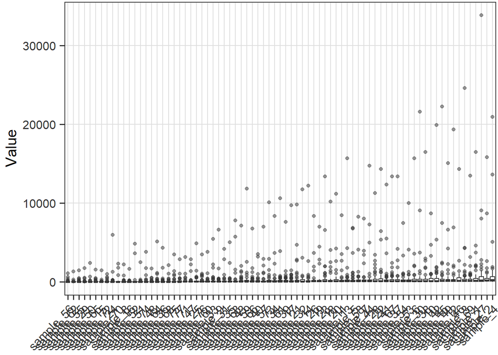

```r
# Datos antes de normalizar
PomaBoxplots(contenedor_cachexia, x = "samples")
```

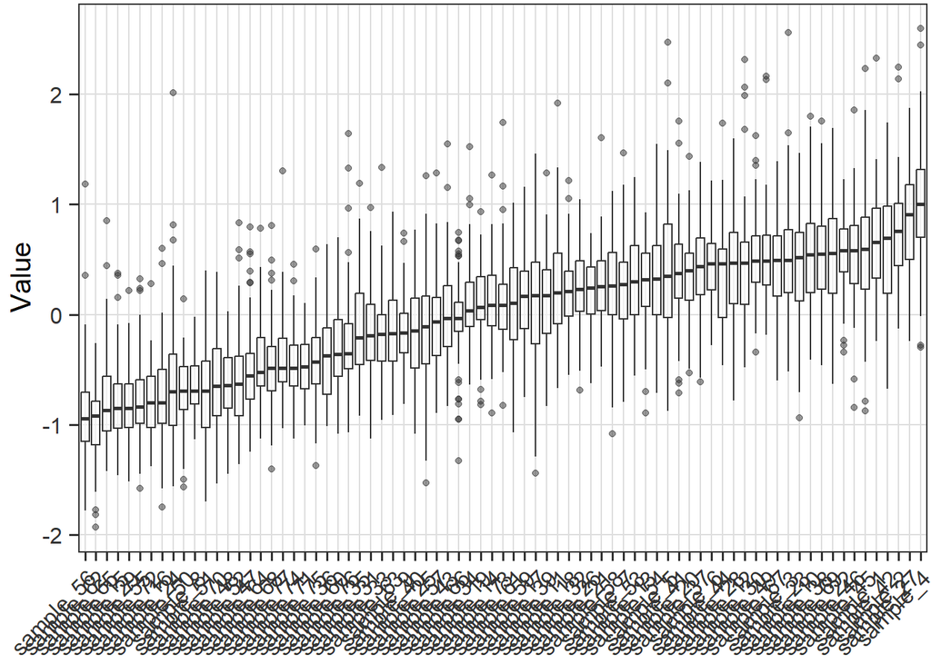

```r
# Datos después de normalizar
PomaBoxplots(contenedor_cachexia_normalizado, x = "samples")
```

Observamos que hemos normalizando correctamente, consiguiendo que los datos sigan una estructura más homogénea.

*Determinar el número de individuos por grupo*

La variable ‘Muscle.loss’ clasifica a los individuos en dos grupos (cachexic y control), por lo que resultaría interesante saber cuantos individuos pertenecen a grupo.

```r
# Calcular el número de individuos pertenecientes a cada grupo (cachexic y control)
muscle_loss <- colData(contenedor_cachexia)$Muscle.loss
conteo_grupos <- table(muscle_loss)
print(conteo_grupos)
```

```
## muscle_loss
## cachexic  control
##       47       30
```

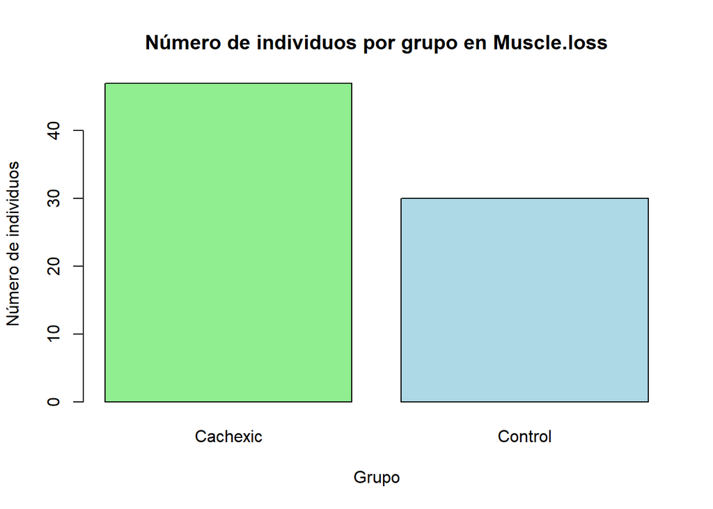

```r
# Representar en un gráfico de barras el número de individuos de cada grupo
barplot(conteo_grupos,
        main="Número de individuos por grupo en Muscle.loss",
        xlab="Grupo",
        ylab="Número de individuos",
        col=c("lightgreen", "lightblue"),
        names.arg=c("Cachexic", "Control"))
```

Hemos obtenido que hay 47 individuos con cachexia y 30 individuos pertenecientes al grupo de control.

*Análisis de expresión diferencial*

Para determinar en qué variables hay diferencias significativas entre los grupos, podemos llevar a cabo un análisis de expresión diferencial.

```r
# Instalar y cargar el paquete limma a través de BiocManager
if (!require("BiocManager", quietly = TRUE))
    install.packages("BiocManager")

BiocManager::install("limma")
library(limma)
# Confirmar que Muscle.loss es un factor
colData(contenedor_cachexia_normalizado)$Muscle.loss <- factor(colData(contenedor_cachexia_normalizado)$Muscle.loss, levels = c("control", "cachexic"))

# Generar la matriz de diseño para limma
matriz_diseño <- model.matrix(~ Muscle.loss, data = colData(contenedor_cachexia_normalizado))

# Realizar el análisis de expresión diferencial y guardar los resultados
ajuste_modelo <- lmFit(assay(contenedor_cachexia_normalizado), matriz_diseño)
ajuste_modelo <- eBayes(ajuste_modelo)
resultados_limma <- topTable(ajuste_modelo, coef = "Muscle.losscachexic", number = Inf)
```

Luego, filtraremos mostrando solo los metabolistos que resultaron significativos (P-value < 0.05).

```r
# Filtrar los metabolitos significativos (P-value < 0.05)
metabolitos_significativos <- resultados_limma[resultados_limma$adj.P.Val < 0.05, ]
print(metabolitos_significativos)
```

```
##                                 logFC       AveExpr        t      P.Value
## Glucose                     0.6802958  2.691750e-16 4.697211 3.205098e-06
## Succinate                   0.6757462  1.914954e-17 4.641316 4.170937e-06
## Creatine                    0.6766538 -7.044780e-17 4.614857 4.720317e-06
## myo.Inositol                0.6323486 -7.736416e-17 4.376158 1.402117e-05
## N.N.Dimethylglycine         0.6224784  2.972685e-17 4.333410 1.695020e-05
## Quinolinate                 0.6067539  1.787892e-16 4.272671 2.213322e-05
## X3.Hydroxyisovalerate       0.6126015 -1.642806e-16 4.264375 2.294887e-05
## Acetate                     0.6032274 -6.533374e-18 4.176671 3.352052e-05
## Glutamine                   0.6018125  3.062125e-16 4.170143 3.446998e-05
## Betaine                     0.5960444 -1.338553e-16 4.124123 4.192691e-05
## cis.Aconitate               0.5978440  4.109267e-17 4.115600 4.346663e-05
## Adipate                     0.5899873 -2.340750e-17 4.107683 4.494489e-05
## Alanine                     0.5824066  2.412843e-17 4.039354 5.984654e-05
## Valine                      0.5600517  3.864829e-17 3.931885 9.311403e-05
## Leucine                     0.5531006 -1.516644e-16 3.895000 1.081143e-04
## X3.Hydroxybutyrate          0.5518837 -2.065898e-17 3.842946 1.332101e-04
## Pyroglutamate               0.5367434 -4.422418e-17 3.740974 1.991178e-04
## Formate                     0.5293944  7.728531e-17 3.691701 2.410073e-04
## Sucrose                     0.5355871 -1.083188e-16 3.683620 2.486227e-04
## Methylamine                 0.5147517  6.540133e-17 3.608545 3.310185e-04
## Tryptophan                  0.5153267 -5.145595e-17 3.602902 3.381492e-04
## Histidine                   0.5164022 -2.175839e-16 3.547807 4.157517e-04
## Tyrosine                    0.5095707  6.907353e-17 3.536354 4.338489e-04
## Dimethylamine               0.5037994  2.449114e-16 3.520414 4.602680e-04
## Lactate                     0.5079505 -1.104816e-16 3.505932 4.855658e-04
## Creatinine                  0.4970437  2.460604e-16 3.473599 5.468118e-04
## Threonine                   0.4830439 -1.478232e-16 3.350278 8.529068e-04
## Pyruvate                    0.4770980 -1.569362e-16 3.300657 1.016084e-03
## X3.Indoxylsulfate           0.4642526  2.247143e-16 3.237853 1.264134e-03
## Trigonelline                0.4657799  1.345875e-16 3.174226 1.571619e-03
## Citrate                     0.4617432 -1.877500e-16 3.167087 1.610123e-03
## Lysine                      0.4542432 -6.676432e-17 3.149604 1.708118e-03
## trans.Aconitate             0.4502345 -4.176854e-17 3.138284 1.774473e-03
## Asparagine                  0.4477735 -1.684259e-16 3.126612 1.845367e-03
## Serine                      0.4479475 -1.105041e-16 3.122216 1.872741e-03
## Xylose                      0.4473094 -6.916928e-17 3.116418 1.909408e-03
## Hippurate                   0.4497108  2.085723e-16 3.078167 2.168390e-03
## Fucose                      0.4223966 -1.961139e-17 2.935233 3.447869e-03
## X2.Aminobutyrate            0.4203962  1.365700e-16 2.929125 3.515452e-03
```

[output cut: 55 more lines]

```
## tau.Methylhistidine         5.944343e-03 -2.41812789
## Fumarate                    6.950571e-03 -2.58876700
## Trimethylamine.N.oxide      6.950571e-03 -2.60077757
## X2.Hydroxyisobutyrate       7.217799e-03 -2.66410370
## O.Acetylcarnitine           7.217799e-03 -2.67557854
## Ethanolamine                8.419115e-03 -2.83183421
## Glycine                     9.600583e-03 -2.98118872
## Taurine                     9.600583e-03 -2.98610143
## pi.Methylhistidine          1.270672e-02 -3.25066134
## Glycolate                   1.968503e-02 -3.64920956
## X1.6.Anhydro.beta.D.glucose 2.042153e-02 -3.69835587
## X2.Oxoglutarate             2.370875e-02 -3.84377163
## Carnitine                   2.659342e-02 -3.95865668
## Guanidoacetate              3.396727e-02 -4.18277528
## X4.Hydroxyphenylacetate     4.373256e-02 -4.41083543
```

Hemos obtenido que para 54 de los 63 metabolitos hay diferencias significativas entre los grupos.

Podemos visualizar gráficamente los resultados de expresión diferencial, por ejemplo mediante un volcano plot.

```r
# Instalar y cargar el paquete EnhancedVolcano a través de BiocManager
if (!require("BiocManager", quietly = TRUE))
    install.packages("BiocManager")

BiocManager::install("EnhancedVolcano")
library(EnhancedVolcano)
# Generar el gráfico
EnhancedVolcano(
  resultados_limma,
  lab = rownames(resultados_limma),
  x = 'logFC',
  y = 'adj.P.Val',
  title = 'Análisis de Expresión Diferencial',
  pCutoff = 0.05,
  FCcutoff = 1
)
```

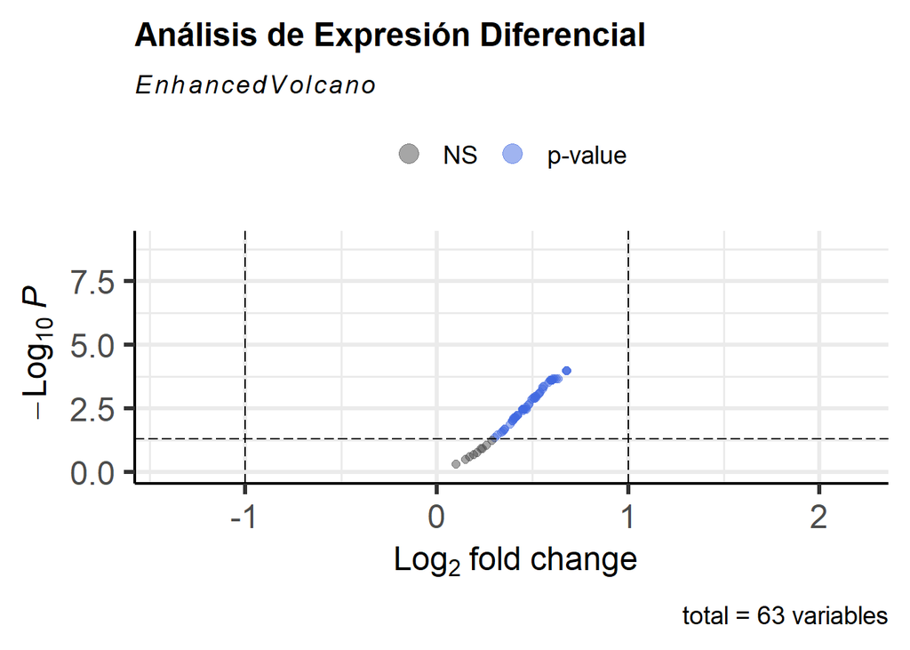

En el volcano plot se resaltan los metabloitos estadísticamente significativos, los cuales corresponden a los que superan la línea del umbra. En este caso están coloreados de azul. Cuanto más a la derecha se encuentren, más se están expresando los metabolitos.

También podemos representar algunas variables de manera independiente. Por ejemplo, representaremos 4 que han resultado significativas en el anterior análisis (Alanine, Creatine, Taurine y Glutamine) y 2 que no (Isoleucine y Acetone).

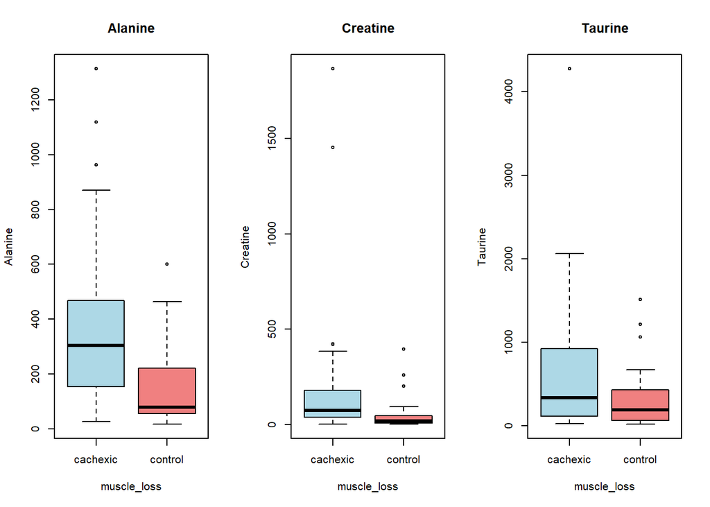

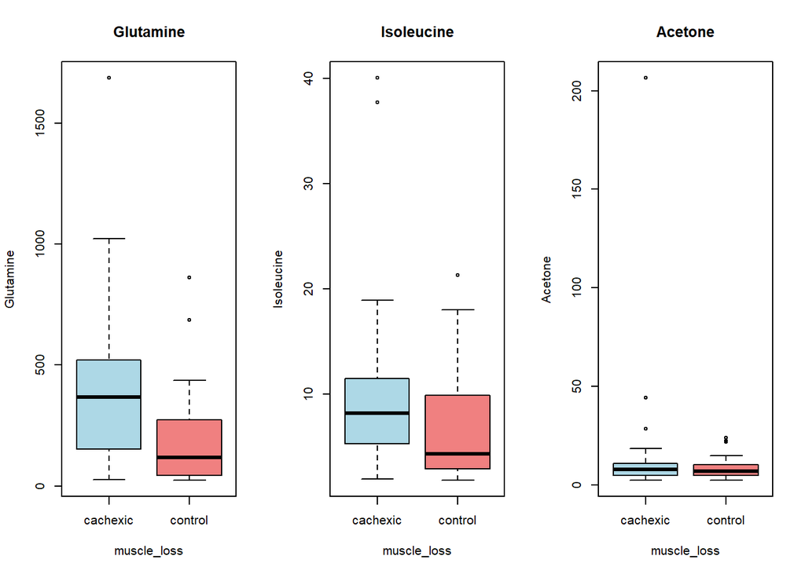

```r
# Seleccionar los metabolitos que vamos a representar
metabolitos_seleccionados <- c("Alanine", "Creatine", "Taurine", "Glutamine", "Isoleucine", "Acetone")

# Crear los boxplot
par(mfrow=c(1, 3))
for (metabolito in metabolitos_seleccionados[1:6]) {
  boxplot(datos_expresion[metabolito, ] ~ muscle_loss,
          main=paste(metabolito),
          ylab=metabolito,
          col=c("lightblue", "lightcoral"))
}
```

```r
par(mfrow=c(1, 2))
```

*PCA*

Podemos realizar un análisis de componentes principales (PCA) para observar si los componentes encajan con nuestros grupos de individuos (cachexic y control).

```r
# Instalar y cargar el paquete PCAtools a través de BiocManager
if (!require("PCAtools", quietly = TRUE))
    BiocManager::install("PCAtools")
library(PCAtools)

# Realizar el PCA
pca <- pca(assay(contenedor_cachexia_normalizado), metadata = colData(contenedor_cachexia_normalizado), removeVar = 0.1)
```

```
## -- removing the lower 10% of variables based on variance
```

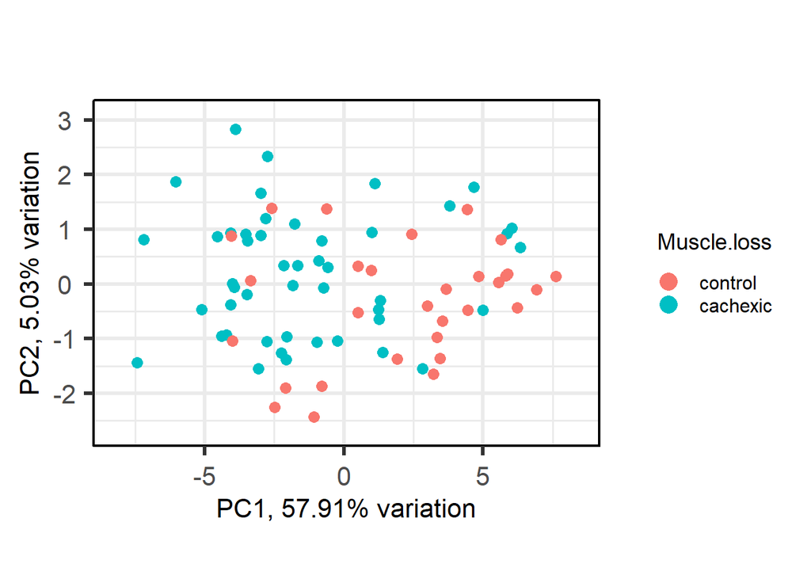

```r
biplot(pca, colby = "Muscle.loss", legendPosition = "right")
```

*Mapa de calor*

Por ultimo, llevar a cabo un mapa de calor permite visualizar si existen patrones de expresión entre las muestras.

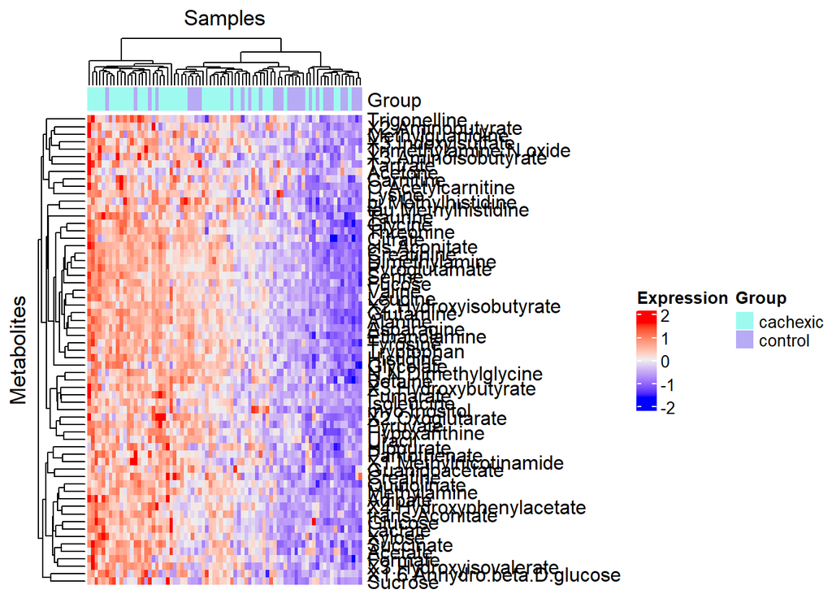

```r
# Instalar y cargar el paquete ComplexHeatmap a través de BiocManager
if (!require("ComplexHeatmap", quietly = TRUE))
    BiocManager::install("ComplexHeatmap")
library(ComplexHeatmap)

# Crear el mapa de calor
Heatmap(
  assay(contenedor_cachexia_normalizado),
  name = "Expression",
  column_title = "Samples",
  row_title = "Metabolites",
  cluster_rows = TRUE,
  cluster_columns = TRUE,
  show_column_names = FALSE,
  top_annotation = HeatmapAnnotation(df = data.frame(Group = colData(contenedor_cachexia)$Muscle.loss))
)
```

Podemos observar que la mayoría de individuos del grupo control se sitúan a la derecha y tienen niveles niveles de expresión más bajos que los individuos con cachexia, los cuales se concentran a la izquierda del gráfico.

# *4. Reposición de los datos en github*

Por último, creamos un repositorio de github donde se adjuntaran todos los entregables de esta PEC. En mi caso, corresponde al siguiente enlace: https://github.com/DanielAcostaBarrios/Acosta-Barrios-Daniel-PEC1